```python
#Preface: Data Science Machine Learning Project deploying Mobile Phone Price data accquired from Kaggle to predict classes of Mobile Phone
#prices based on hardware specifications.
import warnings

import scipy as sp
import pandas as pd
import numpy as npy
import matplotlib.pyplot as mpl
import seaborn as sn
from sklearn.inspection import permutation_importance as perm
from sklearn.ensemble import RandomForestClassifier as rfc
from sklearn.model_selection import train_test_split,cross_val_score,GridSearchCV
from sklearn.preprocessing import label_binarize
from sklearn.metrics import classification_report, confusion_matrix, roc_curve, auc

print('All libraries available, setup successful.')
```

```
All libraries available, setup successful.
```

```python
#Defining df as working data set from kaggle data set folder.
df = pd.read_csv("Mobile Phone Pricing Dataset/Mobile Phone Pricing.csv", encoding='ascii', delimiter=',')
```

# Research Goal

The goal of this project is to build a predictive model that can also act as a prescriptive model built from the Mobile Phone Pricing data provided. The predictive model will be able to forecast the prices of newer models of phones based on the specifications that the model uses to determine the price_range class. The same model can double as a perscriptive model to determine if a model of phone is worth the price:hardware-specification ratio.

```python
df.head() #Header of the data, first five
```

|  | battery_power | blue | clock_speed | dual_sim | fc | four_g | int_memory | m_dep | mobile_wt | n_cores | ... | px_height | px_width | ram | sc_h | sc_w | talk_time | three_g | touch_screen | wifi | price_range |
| --- | --- | --- | --- | --- | --- | --- | --- | --- | --- | --- | --- | --- | --- | --- | --- | --- | --- | --- | --- | --- | --- |
| 0 | 842 | 0 | 2.2 | 0 | 1 | 0 | 7 | 0.6 | 188 | 2 | ... | 20 | 756 | 2549 | 9 | 7 | 19 | 0 | 0 | 1 | 1 |
| 1 | 1021 | 1 | 0.5 | 1 | 0 | 1 | 53 | 0.7 | 136 | 3 | ... | 905 | 1988 | 2631 | 17 | 3 | 7 | 1 | 1 | 0 | 2 |
| 2 | 563 | 1 | 0.5 | 1 | 2 | 1 | 41 | 0.9 | 145 | 5 | ... | 1263 | 1716 | 2603 | 11 | 2 | 9 | 1 | 1 | 0 | 2 |
| 3 | 615 | 1 | 2.5 | 0 | 0 | 0 | 10 | 0.8 | 131 | 6 | ... | 1216 | 1786 | 2769 | 16 | 8 | 11 | 1 | 0 | 0 | 2 |
| 4 | 1821 | 1 | 1.2 | 0 | 13 | 1 | 44 | 0.6 | 141 | 2 | ... | 1208 | 1212 | 1411 | 8 | 2 | 15 | 1 | 1 | 0 | 1 |

5 rows × 21 columns

```python
df.tail() #Tail of the data table, last five
```

|  | battery_power | blue | clock_speed | dual_sim | fc | four_g | int_memory | m_dep | mobile_wt | n_cores | ... | px_height | px_width | ram | sc_h | sc_w | talk_time | three_g | touch_screen | wifi | price_range |
| --- | --- | --- | --- | --- | --- | --- | --- | --- | --- | --- | --- | --- | --- | --- | --- | --- | --- | --- | --- | --- | --- |
| 1995 | 794 | 1 | 0.5 | 1 | 0 | 1 | 2 | 0.8 | 106 | 6 | ... | 1222 | 1890 | 668 | 13 | 4 | 19 | 1 | 1 | 0 | 0 |
| 1996 | 1965 | 1 | 2.6 | 1 | 0 | 0 | 39 | 0.2 | 187 | 4 | ... | 915 | 1965 | 2032 | 11 | 10 | 16 | 1 | 1 | 1 | 2 |
| 1997 | 1911 | 0 | 0.9 | 1 | 1 | 1 | 36 | 0.7 | 108 | 8 | ... | 868 | 1632 | 3057 | 9 | 1 | 5 | 1 | 1 | 0 | 3 |
| 1998 | 1512 | 0 | 0.9 | 0 | 4 | 1 | 46 | 0.1 | 145 | 5 | ... | 336 | 670 | 869 | 18 | 10 | 19 | 1 | 1 | 1 | 0 |
| 1999 | 510 | 1 | 2.0 | 1 | 5 | 1 | 45 | 0.9 | 168 | 6 | ... | 483 | 754 | 3919 | 19 | 4 | 2 | 1 | 1 | 1 | 3 |

5 rows × 21 columns

```python
df.info() #Shows data frame information within panda based view.
```

```
<class 'pandas.core.frame.DataFrame'>
RangeIndex: 2000 entries, 0 to 1999
Data columns (total 21 columns):
 #   Column         Non-Null Count  Dtype
---  ------         --------------  -----
 0   battery_power  2000 non-null   int64
 1   blue           2000 non-null   int64
 2   clock_speed    2000 non-null   float64
 3   dual_sim       2000 non-null   int64
 4   fc             2000 non-null   int64
 5   four_g         2000 non-null   int64
 6   int_memory     2000 non-null   int64
 7   m_dep          2000 non-null   float64
 8   mobile_wt      2000 non-null   int64
 9   n_cores        2000 non-null   int64
 10  pc             2000 non-null   int64
 11  px_height      2000 non-null   int64
 12  px_width       2000 non-null   int64
 13  ram            2000 non-null   int64
 14  sc_h           2000 non-null   int64
 15  sc_w           2000 non-null   int64
 16  talk_time      2000 non-null   int64
 17  three_g        2000 non-null   int64
 18  touch_screen   2000 non-null   int64
 19  wifi           2000 non-null   int64
 20  price_range    2000 non-null   int64
dtypes: float64(2), int64(19)
memory usage: 328.3 KB
```

```python
df.shape #Shape of the data, 2000 entries, 21 variables
```

```
(2000, 21)
```

# Metadata of data set provided by kaggle user

```
Description of columns:
```

- **battery_power:** Battery Capacity in mAh
- **blue:** Has Bluetooth or not
- **clock_speed:** Processor speed.
- **dual_sim:** Has dual sim support or not.
- **fc:** Front camera megapixels.
- **four_g:** Has 4G or not.
- **int_memory:** Internal Memory in GB.
- **m_deep:** Mobile depth in cm.
- **mobile_wt:** Weight in gm.
- **n_cores:** Processor Core Count.
- **pc:** Primary Camera megapixels.
- **px_height:** Pixel Resolution height.
- **px_width:** Pixel Resolution width.
- **ram:** Ram in MB.
- **sc_h:** Mobile Screen height in cm.
- **sc_w:** Mobile Screen width in cm
- **talk_time:** Time a single battery charge will last. In hours.
- **three_g:** Has 3G or not.
- **touch_screen:** Has touch screen or not.
- **wifi:** Has WiFi or not
- **Price_range:** This is the target
  - 0=low cost
  - 1=medium cost
  - 2=high cost
  - 3=very high cost

```python
print('Start of Data Exploration Phase:')
```

```
Start of Data Exploration Phase:
```

```
Correlation heatmap of variables:
```

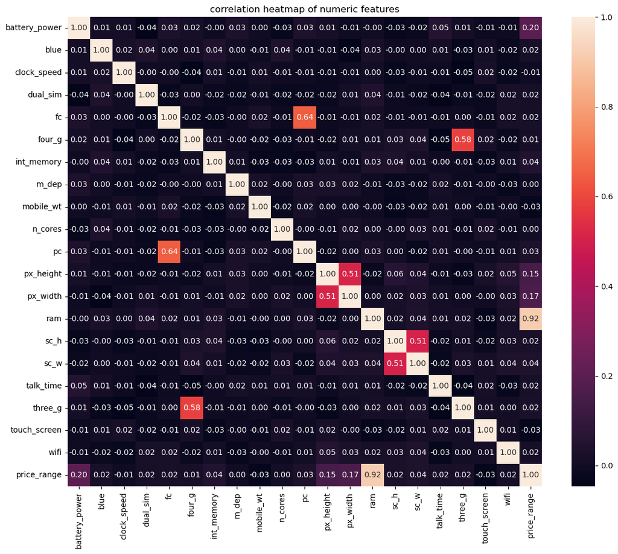

```python
print('Correlation heatmap of variables:')

#Only looking at the numeric or binary values to find outliers and correlations that are of interest for data cleaning and refinement.

#Select for columns with numeric values, those with string values will be omitted.
num_df = df.select_dtypes(include=[npy.number])

sn.color_palette("colorblind")

if num_df.shape[1] >= 4:
    mpl.figure(figsize=(12,10))
    sn.heatmap(num_df.corr(), annot=True, fmt='.2f', cmap='rocket')
    mpl.title('correlation heatmap of numeric features')
    mpl.tight_layout()
    mpl.show()
else:
    print('Not enough numeric features for correlation analysis')
```

```
Sample Distribution of selected features:
```

|  | price_range | battery_power | ram | px_height | px_width |
| --- | --- | --- | --- | --- | --- |
| count | 2000.000000 | 2000.000000 | 2000.000000 | 2000.000000 | 2000.000000 |
| mean | 1.500000 | 1238.518500 | 2124.213000 | 645.108000 | 1251.515500 |
| std | 1.118314 | 439.418206 | 1084.732044 | 443.780811 | 432.199447 |
| min | 0.000000 | 501.000000 | 256.000000 | 0.000000 | 500.000000 |
| 25% | 0.750000 | 851.750000 | 1207.500000 | 282.750000 | 874.750000 |
| 50% | 1.500000 | 1226.000000 | 2146.500000 | 564.000000 | 1247.000000 |
| 75% | 2.250000 | 1615.250000 | 3064.500000 | 947.250000 | 1633.000000 |
| max | 3.000000 | 1998.000000 | 3998.000000 | 1960.000000 | 1998.000000 |

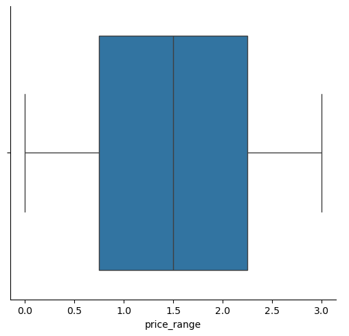

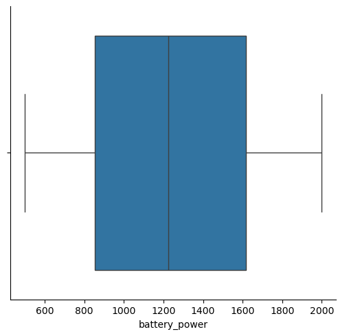

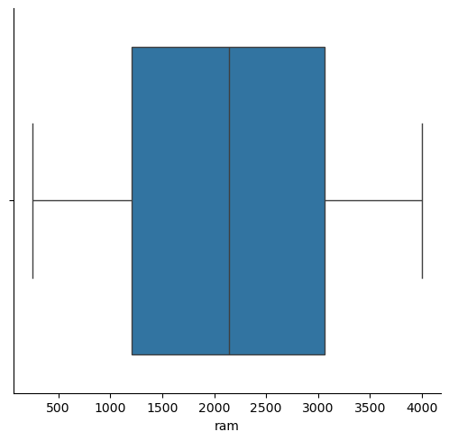

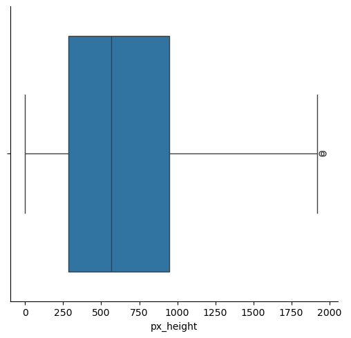

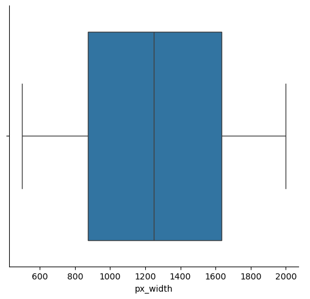

```python
print("Sample Distribution of selected features:")

#selectors for specific columns
selected = df[["price_range","battery_power","ram","px_height","px_width"]]
price = df["price_range"]
bat = df["battery_power"]
ram = df["ram"]
height = df["px_height"]
width = df["px_width"]


display(selected.describe())
sn.catplot(data = df, x="price_range", kind="box")
sn.catplot(data = df, x="battery_power", kind="box")
sn.catplot(data = df, x="ram", kind="box")
sn.catplot(data = df, x="px_height", kind="box")
sn.catplot(data = df, x="px_width", kind="box")
```

```
Box Plots distributions of Features in respect to Price Range categories
```

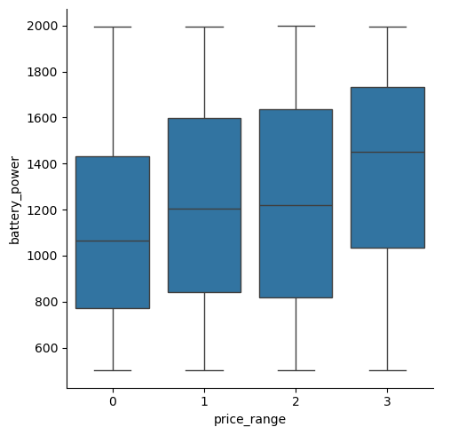

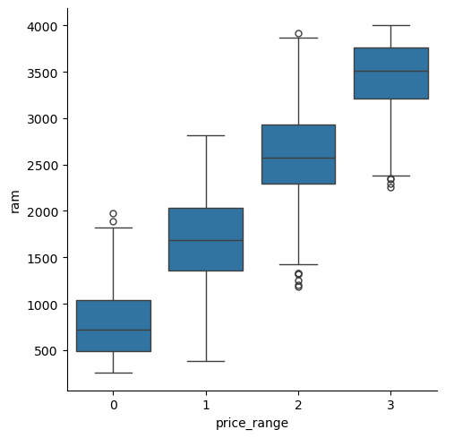

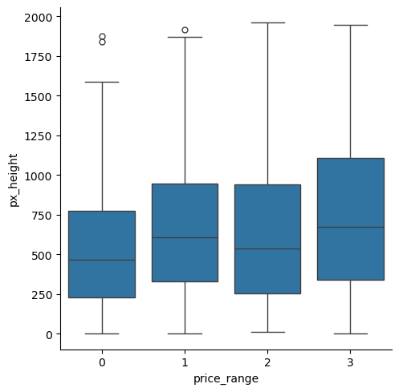

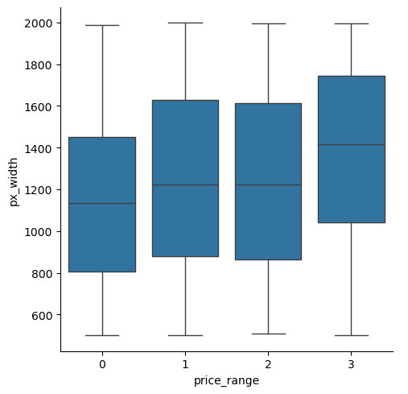

```python
print("Box Plots distributions of Features in respect to Price Range categories")

sn.catplot(data = df, x="price_range", y="battery_power", kind="box")

sn.catplot(data = df, x="price_range", y="ram", kind="box")

sn.catplot(data = df, x="price_range", y="px_height", kind="box")

sn.catplot(data = df, x="price_range", y="px_width", kind="box")
```

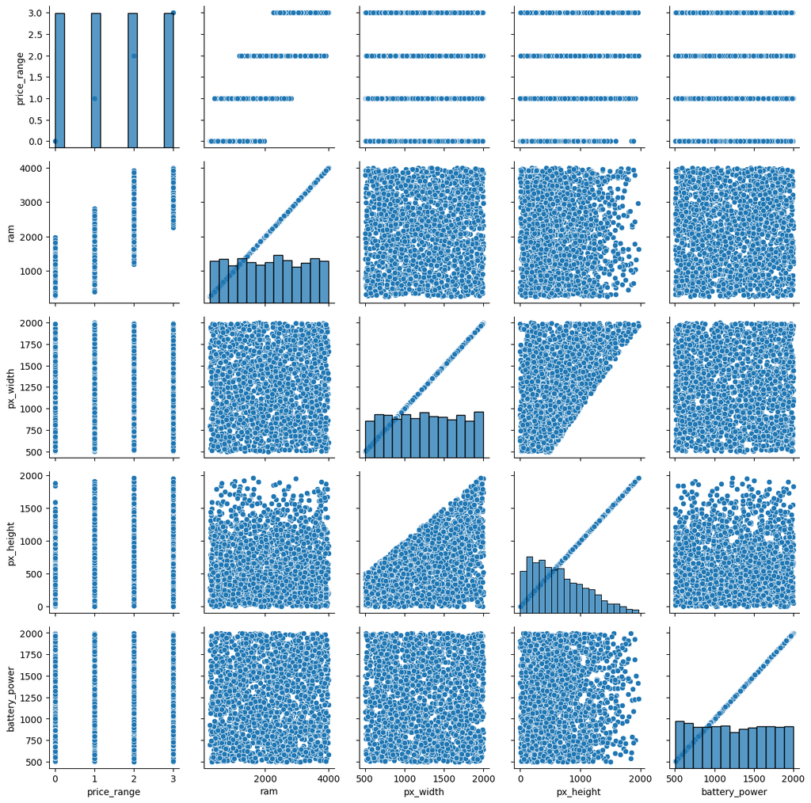

```python
#Dimensionality reduced to 4 features based on exploration data aggregated.
reduce = df[['price_range', 'ram', 'px_width', 'px_height', 'battery_power']]
pairplot = sn.PairGrid(reduce)
pairplot.map_diag(sn.histplot)
pairplot.map(sn.scatterplot)
```

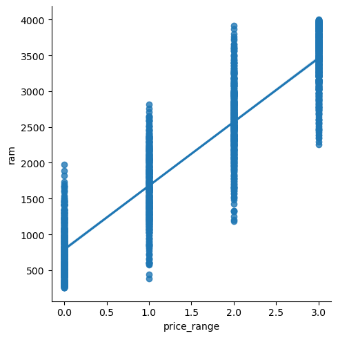

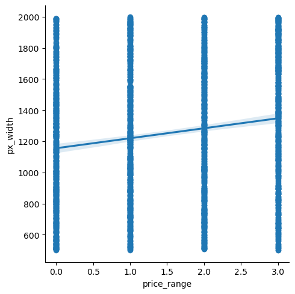

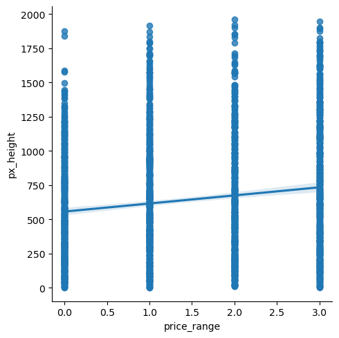

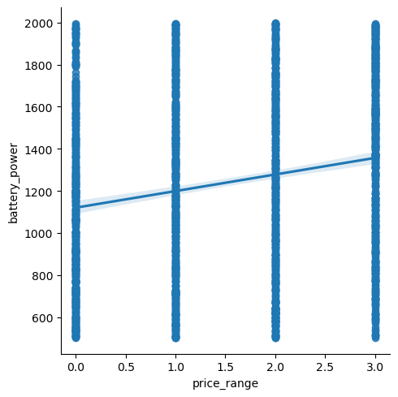

```python
#Analyze the predictive power of each feature before constructing ML model.
sn.lmplot(y="ram", x="price_range", data=df)
sn.lmplot(y="px_width", x="price_range", data=df)
sn.lmplot(y="px_height", x="price_range", data=df)
sn.lmplot(y="battery_power", x="price_range", data=df)
```

# 4 Feature Model Build

We will be utilzing the ram, px_width, px_height and battery_power features to build the predictive/perscriptive model for Mobile Phone Prices. The model will predict which of the 4 classes of Mobile Phone Price_Range it falls into based on the 4 Features explored and picked out. 80% of the data will be used to train the model and 20% will be used to test the model for its accuracy.

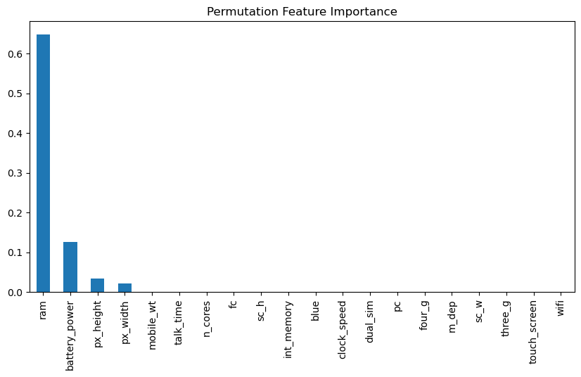

```python
#Further support reduction of feature choice using permutation feature importance plot
x = df.drop('price_range', axis=1)
y = df['price_range']

model = rfc()
model.fit(x,y)

result = perm(model, x, y, n_repeats=20, random_state=42)

perm_importance=pd.Series(result.importances_mean, index=x.columns).sort_values(ascending=False)

perm_importance.plot(kind="bar", figsize=(10, 5))
mpl.title("Permutation Feature Importance")
mpl.show()
```

```python
#Programming the training and testin sets for the perscriptive model
x=reduce.drop('price_range', axis=1)
y=df['price_range']

x_train, x_test, y_train, y_test = train_test_split(x, y, test_size=0.2, random_state=42)
print("Shape of Training Set:")
display(x_train.shape)
print("Shape of Testing Set:")
display(x_test.shape)
```

```
Shape of Training Set:
```

```
(1600, 4)
```

```
Shape of Testing Set:
```

```
(400, 4)
```

```python
#bias model building with 4 chosen features

modelx4 = rfc()
scores = cross_val_score(modelx4, x_train, y_train, cv=3)

print("Cross Value Summary:")
print("Cross Value Scores:", scores)
print("Average Cross Value Score:", scores.mean())
print("Range of Cross Value Scores:", (scores.max()-scores.min()))

modelx4.fit(x_train, y_train)
test_accuracy = modelx4.score(x_test, y_test)

y_pred=modelx4.predict(x_test)

print("Accuracy based on test set:", test_accuracy)
```

```
Cross Value Summary:
Cross Value Scores: [0.90636704 0.90619137 0.87804878]
Average Cross Value Score: 0.8968690637641035
Range of Cross Value Scores: 0.028318260710696985
Accuracy based on test set: 0.93
```

The cross value of the model has a high cross value score mean, which indicates the model performs well. The range of the cross value scores is also small, so the overall, the cross-value scores supports the 4F Model performance. The accuracy of the model further supports its performance with a accuracy score >90%

```
Testing for strength and accuracy of model -
```

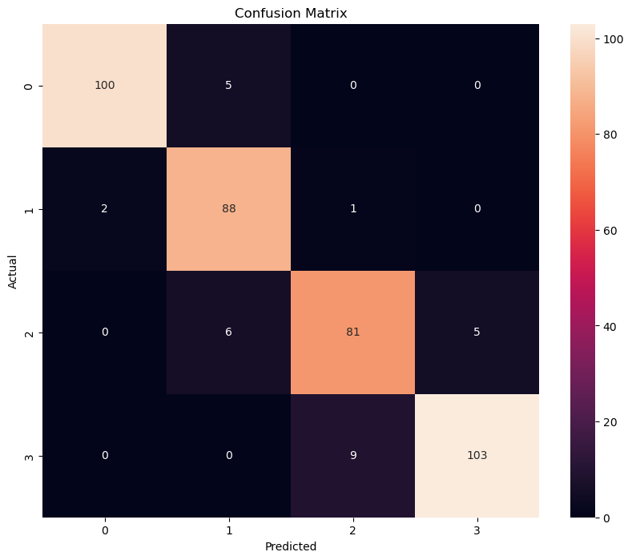

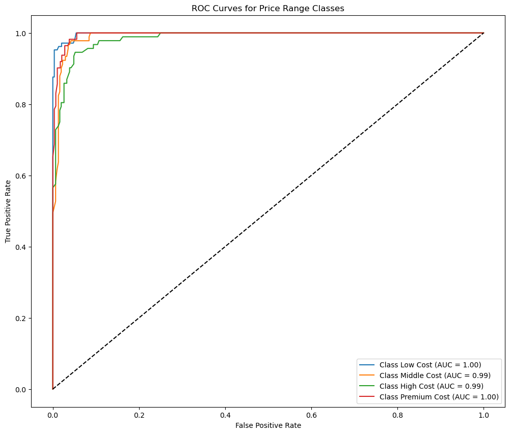

```python
print("Testing for strength and accuracy of model -")

#Confusion matrix of Rainforest Classifier model with 4 features
cmx = confusion_matrix(y_test, y_pred)
mpl.figure(figsize=(10,8))
sn.heatmap(cmx, annot=True, fmt='d', cmap='rocket')
mpl.title('Confusion Matrix')
mpl.xlabel('Predicted')
mpl.ylabel('Actual')
mpl.show()

#Receiving Operating Characterisitc Curve for Multiple Price Range Classes based model.
#Class meanings of Price Ranges: 0 - Low Cost, 1 - Middle Cost, 2 - High Cost, 3 - Premium Cost

def price_indicator(i): #function to define each class based on metadata information provided by Kaggle
    if i==0:
        return "Low Cost"
    if i==1:
        return "Middle Cost"
    if i==2:
        return "High Cost"
    if i==3:
        return "Premium Cost"


prices_c = sorted(y.unique())
y_test_bin=label_binarize(y_test, classes=prices_c)
n_classes = y_test_bin.shape[1]

y_score = modelx4.predict_proba(x_test)

mpl.figure(figsize=(12,10))
for i in range(n_classes):
        fpr, tpr, _ = roc_curve(y_test_bin[:,i], y_score[:,i])
        roc_auc=auc(fpr,tpr)
        mpl.plot(fpr, tpr, label=f'Class {price_indicator(prices_c[i])} (AUC = {roc_auc:.2f})')
mpl.plot([0,1], [0,1], 'k--')
mpl.xlabel('False Positive Rate')
mpl.ylabel('True Positive Rate')
mpl.title('ROC Curves for Price Range Classes')
mpl.legend(loc='lower right')
mpl.show()
```